# Project-Level 27 BalDS-Final

```python
pwd
```

```
'C:\\Users\\sharlin.kahlon'
```

```python
import numpy as np
import pandas as pd
import seaborn as sns
from matplotlib import pyplot as plt
import matplotlib
%matplotlib inline
```

Dataset loading to dataframe df

```python
#Loading Dataset
df= pd.read_csv("SKDataset-finalProject.csv", sep=",")
df.head()
```

|  | id | Issue_Date | Emp_Length_Int | Home_Ownership | Annual_Income | Loan_Amount | Term | Purpose | Interest_Payments | Loan_Status | Interest_Rate | DTI | Total_Payment | Total_Rec_Prncp | Installment | Region |
| --- | --- | --- | --- | --- | --- | --- | --- | --- | --- | --- | --- | --- | --- | --- | --- | --- |
| 0 | 643218 | 01-12-2010 | 7.0 | MORTGAGE | 45000 | 20000.0 | 60 months | debt_consolidation | Low | Good Loan | 9.99 | 13.36 | 24421.720000 | 20000.00 | 424.85 | ulster |
| 1 | 642872 | 01-12-2010 | 0.5 | OWN | 145000 | 7475.0 | 60 months | debt_consolidation | High | Good Loan | 13.72 | 17.39 | 10370.742730 | 7475.00 | 172.85 | leinster |
| 2 | 642861 | 01-12-2010 | 0.5 | MORTGAGE | 120000 | 5575.0 | 36 months | small_business | High | Good Loan | 15.20 | 16.40 | 6819.090000 | 5574.99 | 193.81 | Northern-Irl |
| 3 | 642859 | 01-12-2010 | 0.5 | RENT | 120000 | 2150.0 | 60 months | debt_consolidation | High | Good Loan | 14.83 | 6.16 | 2816.830000 | 2150.00 | 50.96 | Northern-Irl |
| 4 | 642857 | 01-12-2010 | 0.5 | MORTGAGE | 140000 | 7050.0 | 60 months | moving | Low | Good Loan | 12.98 | 4.26 | 9619.300001 | 7050.00 | 160.34 | ulster |

```python
df.shape
```

```
(74181, 16)
```

```python
df.info()
```

```
<class 'pandas.core.frame.DataFrame'>
RangeIndex: 74181 entries, 0 to 74180
Data columns (total 16 columns):
 #   Column             Non-Null Count  Dtype
---  ------             --------------  -----
 0   id                 74181 non-null  int64
 1   Issue_Date         74181 non-null  object
 2   Emp_Length_Int     74181 non-null  float64
 3   Home_Ownership     74131 non-null  object
 4   Annual_Income      74181 non-null  int64
 5   Loan_Amount        74161 non-null  float64
 6   Term               74181 non-null  object
 7   Purpose            74181 non-null  object
 8   Interest_Payments  74181 non-null  object
 9   Loan_Status        74181 non-null  object
 10  Interest_Rate      74181 non-null  float64
 11  DTI                74181 non-null  float64
 12  Total_Payment      74181 non-null  float64
 13  Total_Rec_Prncp    74181 non-null  float64
 14  Installment        74181 non-null  float64
 15  Region             74169 non-null  object
dtypes: float64(7), int64(2), object(7)
memory usage: 9.1+ MB
```

```python
df.isnull().sum()
```

```
id                    0
Issue_Date            0
Emp_Length_Int        0
Home_Ownership       50
Annual_Income         0
Loan_Amount          20
Term                  0
Purpose               0
Interest_Payments     0
Loan_Status           0
Interest_Rate         0
DTI                   0
Total_Payment         0
Total_Rec_Prncp       0
Installment           0
Region               12
dtype: int64
```

Missing Values are removed using mean and mode.

```python
#Missing Values for numerical
df['Loan_Amount']= df['Loan_Amount'].fillna(df['Loan_Amount'].mean())
```

```python
#for categorical
df['Region']= df['Region'].fillna(df['Region'].mode()[0])
df['Home_Ownership']= df['Home_Ownership'].fillna(df['Home_Ownership'].mode()[0])
```

```python
df.isnull().sum()
```

```
id                   0
Issue_Date           0
Emp_Length_Int       0
Home_Ownership       0
Annual_Income        0
Loan_Amount          0
Term                 0
Purpose              0
Interest_Payments    0
Loan_Status          0
Interest_Rate        0
DTI                  0
Total_Payment        0
Total_Rec_Prncp      0
Installment          0
Region               0
dtype: int64
```

```python
#Label Encoding
df.replace({"Loan_Status":{'Bad Loan':0,'Good Loan':1}},inplace= True)
```

```python
df.head()
```

|  | id | Issue_Date | Emp_Length_Int | Home_Ownership | Annual_Income | Loan_Amount | Term | Purpose | Interest_Payments | Loan_Status | Interest_Rate | DTI | Total_Payment | Total_Rec_Prncp | Installment | Region |
| --- | --- | --- | --- | --- | --- | --- | --- | --- | --- | --- | --- | --- | --- | --- | --- | --- |
| 0 | 643218 | 01-12-2010 | 7.0 | MORTGAGE | 45000 | 20000.0 | 60 months | debt_consolidation | Low | 1 | 9.99 | 13.36 | 24421.720000 | 20000.00 | 424.85 | ulster |
| 1 | 642872 | 01-12-2010 | 0.5 | OWN | 145000 | 7475.0 | 60 months | debt_consolidation | High | 1 | 13.72 | 17.39 | 10370.742730 | 7475.00 | 172.85 | leinster |
| 2 | 642861 | 01-12-2010 | 0.5 | MORTGAGE | 120000 | 5575.0 | 36 months | small_business | High | 1 | 15.20 | 16.40 | 6819.090000 | 5574.99 | 193.81 | Northern-Irl |
| 3 | 642859 | 01-12-2010 | 0.5 | RENT | 120000 | 2150.0 | 60 months | debt_consolidation | High | 1 | 14.83 | 6.16 | 2816.830000 | 2150.00 | 50.96 | Northern-Irl |
| 4 | 642857 | 01-12-2010 | 0.5 | MORTGAGE | 140000 | 7050.0 | 60 months | moving | Low | 1 | 12.98 | 4.26 | 9619.300001 | 7050.00 | 160.34 | ulster |

Descriptive Statistics- This is to calculate basic statistics for all continous variables. Describe functions- give values of Mean, IQR values, Min, Max value and Standard Deviation

# For Numerical attributes:-

```python
df.describe()
```

|  | id | Emp_Length_Int | Annual_Income | Loan_Amount | Loan_Status | Interest_Rate | DTI | Total_Payment | Total_Rec_Prncp | Installment |
| --- | --- | --- | --- | --- | --- | --- | --- | --- | --- | --- |
| count | 7.418100e+04 | 74181.000000 | 7.418100e+04 | 74181.000000 | 74181.000000 | 74181.000000 | 74181.000000 | 74181.000000 | 74181.000000 | 74181.000000 |
| mean | 1.237230e+06 | 5.486336 | 6.946324e+04 | 12515.776149 | 0.843868 | 13.207386 | 15.600123 | 13408.011613 | 10651.045665 | 389.389523 |
| std | 5.702563e+05 | 3.466796 | 6.455445e+04 | 7793.699152 | 0.362983 | 4.131073 | 7.544646 | 9281.509370 | 7350.064745 | 239.220559 |
| min | 5.473400e+04 | 0.500000 | 1.896000e+03 | 500.000000 | 0.000000 | 5.420000 | 0.000000 | 0.000000 | 0.000000 | 15.670000 |
| 25% | 6.073330e+05 | 2.000000 | 4.200000e+04 | 6400.000000 | 1.000000 | 10.160000 | 9.970000 | 6444.386955 | 5000.000000 | 205.010000 |
| 50% | 1.325061e+06 | 5.000000 | 6.000000e+04 | 10250.000000 | 1.000000 | 13.110000 | 15.450000 | 11445.370000 | 9600.000000 | 343.390000 |
| 75% | 1.550404e+06 | 10.000000 | 8.320000e+04 | 17050.000000 | 1.000000 | 15.800000 | 20.990000 | 18205.170000 | 14950.000000 | 515.740000 |
| max | 2.844673e+06 | 10.000000 | 7.141778e+06 | 35000.000000 | 1.000000 | 24.890000 | 34.990000 | 57777.579870 | 35000.010000 | 1388.450000 |

Summary Statistics of character column.

```python
df.describe(include=['object'])
```

|  | Issue_Date | Home_Ownership | Term | Purpose | Interest_Payments | Region |
| --- | --- | --- | --- | --- | --- | --- |
| count | 74181 | 74181 | 74181 | 74181 | 74181 | 74181 |
| unique | 55 | 4 | 2 | 14 | 2 | 5 |
| top | 01-11-2012 | RENT | 36 months | debt_consolidation | Low | ulster |
| freq | 6382 | 34413 | 60903 | 39917 | 39226 | 19394 |

Median

```python
df.median()
```

```
id                 1325061.00
Emp_Length_Int           5.00
Annual_Income        60000.00
Loan_Amount          10250.00
Loan_Status              1.00
Interest_Rate           13.11
DTI                     15.45
Total_Payment        11445.37
Total_Rec_Prncp       9600.00
Installment            343.39
dtype: float64
```

Mode

```python
df.mode()
```

|  | id | Issue_Date | Emp_Length_Int | Home_Ownership | Annual_Income | Loan_Amount | Term | Purpose | Interest_Payments | Loan_Status | Interest_Rate | DTI | Total_Payment | Total_Rec_Prncp | Installment | Region |
| --- | --- | --- | --- | --- | --- | --- | --- | --- | --- | --- | --- | --- | --- | --- | --- | --- |
| 0 | 54734 | 01-11-2012 | 10.0 | RENT | 60000.0 | 10000.0 | 36 months | debt_consolidation | Low | 1.0 | 12.12 | 0.0 | 11977.77039 | 10000.0 | 332.72 | ulster |
| 1 | 55521 | NaN | NaN | NaN | NaN | NaN | NaN | NaN | NaN | NaN | NaN | NaN | NaN | NaN | NaN | NaN |
| 2 | 55742 | NaN | NaN | NaN | NaN | NaN | NaN | NaN | NaN | NaN | NaN | NaN | NaN | NaN | NaN | NaN |
| 3 | 56413 | NaN | NaN | NaN | NaN | NaN | NaN | NaN | NaN | NaN | NaN | NaN | NaN | NaN | NaN | NaN |
| 4 | 57245 | NaN | NaN | NaN | NaN | NaN | NaN | NaN | NaN | NaN | NaN | NaN | NaN | NaN | NaN | NaN |
| ... | ... | ... | ... | ... | ... | ... | ... | ... | ... | ... | ... | ... | ... | ... | ... | ... |
| 74176 | 2837228 | NaN | NaN | NaN | NaN | NaN | NaN | NaN | NaN | NaN | NaN | NaN | NaN | NaN | NaN | NaN |
| 74177 | 2837301 | NaN | NaN | NaN | NaN | NaN | NaN | NaN | NaN | NaN | NaN | NaN | NaN | NaN | NaN | NaN |
| 74178 | 2837644 | NaN | NaN | NaN | NaN | NaN | NaN | NaN | NaN | NaN | NaN | NaN | NaN | NaN | NaN | NaN |
| 74179 | 2837824 | NaN | NaN | NaN | NaN | NaN | NaN | NaN | NaN | NaN | NaN | NaN | NaN | NaN | NaN | NaN |
| 74180 | 2844673 | NaN | NaN | NaN | NaN | NaN | NaN | NaN | NaN | NaN | NaN | NaN | NaN | NaN | NaN | NaN |

74181 rows × 16 columns

Exploratory Data Analysis

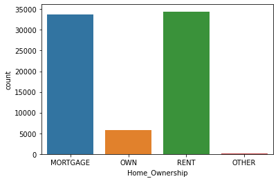

```python
sns.countplot(df['Home_Ownership'])
```

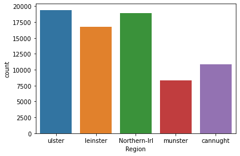

```python
sns.countplot(df['Region'])
```

We can say data is imbalanced - hence we need to balance dataset for better accuracy.

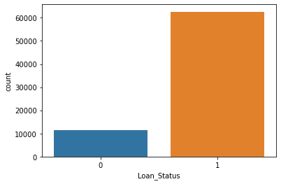

```python
sns.countplot(df['Loan_Status'])
```

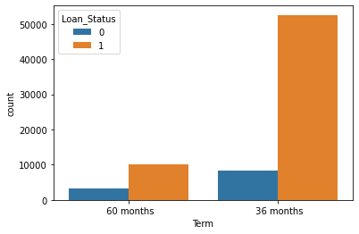

```python
sns.countplot(x='Term', hue='Loan_Status', data=df)
```

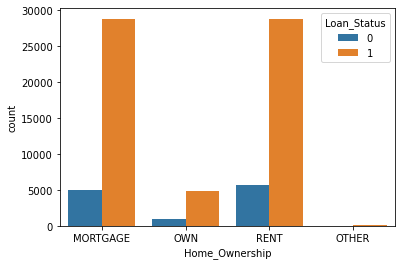

```python
sns.countplot(x='Home_Ownership', hue='Loan_Status', data=df)
```

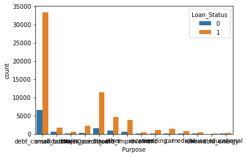

```python
sns.countplot(x='Purpose', hue='Loan_Status', data=df)
```

EDA based on Visualization of Numerical Attributes.

```python
#import matplotlib.pyplot as plt
#bin_limit= [0,5000,10000, 15000, 20000,25000, 30000,35000, 40000]
#plt.hist(df['Loan_Amount'], bins=bin_limit)
```

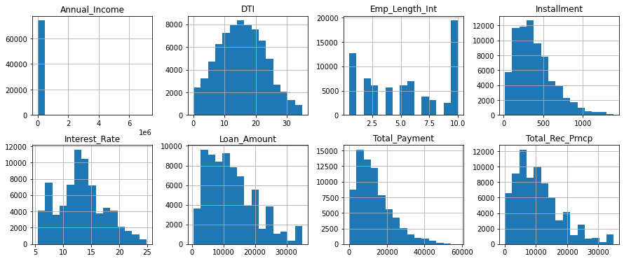

```python
numerical = ['Emp_Length_Int', 'Annual_Income', 'Loan_Amount', 'Interest_Rate', 'DTI', 'Total_Payment', 'Installment', 'Total_Rec_Prncp']
df[numerical].hist(bins=15, figsize=(15, 6), layout=(2, 4));
```

```python
df.head()
```

|  | id | Issue_Date | Emp_Length_Int | Home_Ownership | Annual_Income | Loan_Amount | Term | Purpose | Interest_Payments | Loan_Status | Interest_Rate | DTI | Total_Payment | Total_Rec_Prncp | Installment | Region |
| --- | --- | --- | --- | --- | --- | --- | --- | --- | --- | --- | --- | --- | --- | --- | --- | --- |
| 0 | 643218 | 01-12-2010 | 7.0 | MORTGAGE | 45000 | 20000.0 | 60 months | debt_consolidation | Low | 1 | 9.99 | 13.36 | 24421.720000 | 20000.00 | 424.85 | ulster |
| 1 | 642872 | 01-12-2010 | 0.5 | OWN | 145000 | 7475.0 | 60 months | debt_consolidation | High | 1 | 13.72 | 17.39 | 10370.742730 | 7475.00 | 172.85 | leinster |
| 2 | 642861 | 01-12-2010 | 0.5 | MORTGAGE | 120000 | 5575.0 | 36 months | small_business | High | 1 | 15.20 | 16.40 | 6819.090000 | 5574.99 | 193.81 | Northern-Irl |
| 3 | 642859 | 01-12-2010 | 0.5 | RENT | 120000 | 2150.0 | 60 months | debt_consolidation | High | 1 | 14.83 | 6.16 | 2816.830000 | 2150.00 | 50.96 | Northern-Irl |
| 4 | 642857 | 01-12-2010 | 0.5 | MORTGAGE | 140000 | 7050.0 | 60 months | moving | Low | 1 | 12.98 | 4.26 | 9619.300001 | 7050.00 | 160.34 | ulster |

Correlation Matrix

[output not shown]

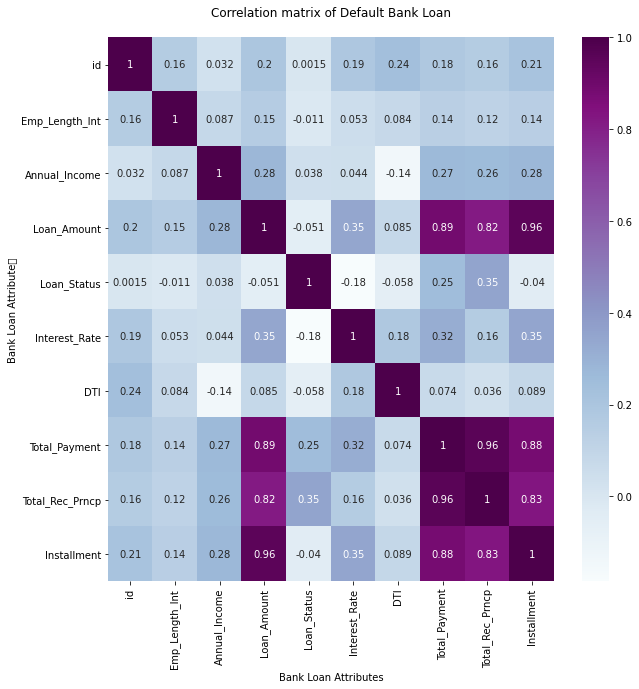

```python
corr = df.corr()
plt.figure(figsize=(10,10))
cm= sns.heatmap(corr, annot=True, cmap="BuPu")
cm.set(xlabel='Bank Loan Attributes', ylabel='Bank Loan Attribute\t', title = "Correlation matrix of Default Bank Loan\n")
```

Drop Unnecessary and highly correlated columns!

```python
df = df.drop(columns=["Total_Rec_Prncp", "Installment", "id", "Issue_Date"], axis=1)
df.head()
```

|  | Emp_Length_Int | Home_Ownership | Annual_Income | Loan_Amount | Term | Purpose | Interest_Payments | Loan_Status | Interest_Rate | DTI | Total_Payment | Region |
| --- | --- | --- | --- | --- | --- | --- | --- | --- | --- | --- | --- | --- |
| 0 | 7.0 | MORTGAGE | 45000 | 20000.0 | 60 months | debt_consolidation | Low | 1 | 9.99 | 13.36 | 24421.720000 | ulster |
| 1 | 0.5 | OWN | 145000 | 7475.0 | 60 months | debt_consolidation | High | 1 | 13.72 | 17.39 | 10370.742730 | leinster |
| 2 | 0.5 | MORTGAGE | 120000 | 5575.0 | 36 months | small_business | High | 1 | 15.20 | 16.40 | 6819.090000 | Northern-Irl |
| 3 | 0.5 | RENT | 120000 | 2150.0 | 60 months | debt_consolidation | High | 1 | 14.83 | 6.16 | 2816.830000 | Northern-Irl |
| 4 | 0.5 | MORTGAGE | 140000 | 7050.0 | 60 months | moving | Low | 1 | 12.98 | 4.26 | 9619.300001 | ulster |

```python
df.shape
```

```
(74181, 12)
```

Label Encoding is to change categorical into numerical value, is coded as follow:

```python
#converting categorical into Numerical
df.replace({"Home_Ownership":{'MORTGAGE':1,'OWN':2, 'RENT':3, 'OTHER':4}},inplace= True)
df.replace({"Interest_Payments":{'Low':0,'High':2}},inplace= True)
df.replace({"Region":{'cannught':0,'leinster':1, 'munster':2, 'Northern-Irl':4, 'ulster':5}},inplace= True)
df.head()
```

|  | Emp_Length_Int | Home_Ownership | Annual_Income | Loan_Amount | Term | Purpose | Interest_Payments | Loan_Status | Interest_Rate | DTI | Total_Payment | Region |
| --- | --- | --- | --- | --- | --- | --- | --- | --- | --- | --- | --- | --- |
| 0 | 7.0 | 1 | 45000 | 20000.0 | 60 months | debt_consolidation | 0 | 1 | 9.99 | 13.36 | 24421.720000 | 5 |
| 1 | 0.5 | 2 | 145000 | 7475.0 | 60 months | debt_consolidation | 2 | 1 | 13.72 | 17.39 | 10370.742730 | 1 |
| 2 | 0.5 | 1 | 120000 | 5575.0 | 36 months | small_business | 2 | 1 | 15.20 | 16.40 | 6819.090000 | 4 |
| 3 | 0.5 | 3 | 120000 | 2150.0 | 60 months | debt_consolidation | 2 | 1 | 14.83 | 6.16 | 2816.830000 | 4 |
| 4 | 0.5 | 1 | 140000 | 7050.0 | 60 months | moving | 0 | 1 | 12.98 | 4.26 | 9619.300001 | 5 |

[output not shown]

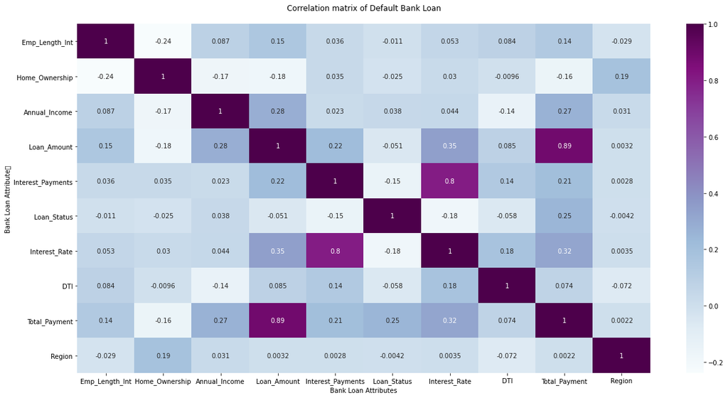

```python
corr = df.corr()
plt.figure(figsize=(20,10))
cm= sns.heatmap(corr, annot=True, cmap="BuPu")
cm.set(xlabel='Bank Loan Attributes', ylabel='Bank Loan Attribute\t', title = "Correlation matrix of Default Bank Loan\n")
```

```python
#Emp length is float and home ownership( we already replaced with numerical value), purpose, and term are nominal values
nominal_columns= ["Term", "Purpose"]
dummy_df = pd.get_dummies(df[nominal_columns])
df= pd.concat([df, dummy_df], axis=1)
df= df.drop(nominal_columns, axis=1)
df.head()
```

|  | Emp_Length_Int | Home_Ownership | Annual_Income | Loan_Amount | Interest_Payments | Loan_Status | Interest_Rate | DTI | Total_Payment | Region | ... | Purpose_home_improvement | Purpose_house | Purpose_major_purchase | Purpose_medical | Purpose_moving | Purpose_other | Purpose_renewable_energy | Purpose_small_business | Purpose_vacation | Purpose_wedding |
| --- | --- | --- | --- | --- | --- | --- | --- | --- | --- | --- | --- | --- | --- | --- | --- | --- | --- | --- | --- | --- | --- |
| 0 | 7.0 | 1 | 45000 | 20000.0 | 0 | 1 | 9.99 | 13.36 | 24421.720000 | 5 | ... | 0 | 0 | 0 | 0 | 0 | 0 | 0 | 0 | 0 | 0 |
| 1 | 0.5 | 2 | 145000 | 7475.0 | 2 | 1 | 13.72 | 17.39 | 10370.742730 | 1 | ... | 0 | 0 | 0 | 0 | 0 | 0 | 0 | 0 | 0 | 0 |
| 2 | 0.5 | 1 | 120000 | 5575.0 | 2 | 1 | 15.20 | 16.40 | 6819.090000 | 4 | ... | 0 | 0 | 0 | 0 | 0 | 0 | 0 | 1 | 0 | 0 |
| 3 | 0.5 | 3 | 120000 | 2150.0 | 2 | 1 | 14.83 | 6.16 | 2816.830000 | 4 | ... | 0 | 0 | 0 | 0 | 0 | 0 | 0 | 0 | 0 | 0 |
| 4 | 0.5 | 1 | 140000 | 7050.0 | 0 | 1 | 12.98 | 4.26 | 9619.300001 | 5 | ... | 0 | 0 | 0 | 0 | 1 | 0 | 0 | 0 | 0 | 0 |

5 rows × 26 columns

```python
#Separating Data and Label
X=df.drop(columns=['Loan_Status'], axis=1)
Y=df['Loan_Status']

print(X)
print(Y)
```

```
       Emp_Length_Int  Home_Ownership  Annual_Income  Loan_Amount  \
0                7.00               1          45000      20000.0
1                0.50               2         145000       7475.0
2                0.50               1         120000       5575.0
3                0.50               3         120000       2150.0
4                0.50               1         140000       7050.0
...               ...             ...            ...          ...
74176            7.00               3          60000      20500.0
74177            3.00               3          57600      15000.0
74178            3.00               1         160000      35000.0
74179            6.05               1          35000      12000.0
74180            7.00               3          50000      12000.0

       Interest_Payments  Interest_Rate    DTI  Total_Payment  Region  \
0                      0           9.99  13.36   24421.720000       5
```

[output cut: 76 more lines]

```python
#Split Data
from sklearn.model_selection import train_test_split
from sklearn.metrics import accuracy_score

X_train, X_test, Y_train, Y_test= train_test_split(X,Y,test_size=0.2,stratify=Y,random_state=20)

print(X.shape, X_train.shape, X_test.shape)
print(Y_train.shape)
```

```
(74181, 25) (59344, 25) (14837, 25)
(59344,)
```

Due to data imbalancing- accuracy seems more than actual. To implement- SMOTE- Synthetic Minority Oversampling Technique. Imbalancing could be fixed with either Under-sampling or Oversampling. Under-sampling loses data, so we prefer over-sampling with random figures synthetically using SMOTE.

Due to stratified sampling, we can see below Y_train has equal class distribution as its orginal class before train test split.

```python
from collections import Counter
Counter(Y_train)
```

```
Counter({1: 50079, 0: 9265})
```

```python
print(X_train.shape)
print(Y_train.shape, Y_test.shape)
```

```
(59344, 25)
(59344,) (14837,)
```

```python
pip install imblearn --user
```

```python
from imblearn.over_sampling import SMOTE
smote = SMOTE()
```

```python
X_train_smote, Y_train_smote = smote.fit_resample(X_train, Y_train)
```

```python
from collections import Counter
print("Before SMOTE:", Counter(Y_train))
print("After SMOTE:", Counter(Y_train_smote))
```

```
Before SMOTE: Counter({1: 50079, 0: 9265})
After SMOTE: Counter({1: 50079, 0: 50079})
```

```python
print(X_train_smote)
```

```
        Emp_Length_Int  Home_Ownership  Annual_Income   Loan_Amount  \
0            10.000000               1          60000  12000.000000
1             5.000000               1          57000  12000.000000
2             6.000000               3          50000  17600.000000
3            10.000000               1          60000   7925.000000
4             8.000000               3          45000   6000.000000
...                ...             ...            ...           ...
100153        2.959306               3          96000  21000.000000
100154        8.612436               1          75000   9583.730756
100155        0.856664               3         113286  35000.000000
100156        6.111126               3          39999   4955.556305
100157        9.786691               1          65159  32491.317021

        Interest_Payments  Interest_Rate        DTI  Total_Payment  Region  \
0                       2      14.330000  30.380000   14831.056010       0
```

[output cut: 64 more lines]

Model Training

```python
from sklearn.linear_model import LogisticRegression
from sklearn.tree import DecisionTreeClassifier
from sklearn.ensemble import RandomForestClassifier
from sklearn import svm
from sklearn.svm import SVC
from sklearn import metrics
from sklearn.metrics import accuracy_score
```

```python
modelSm= RandomForestClassifier()
modelSm.fit(X_train_smote, Y_train_smote)
y_randomforest = modelSm.predict(X_test)
print("Accuracy is:", metrics.accuracy_score(Y_test, y_randomforest)*100)
```

```
Accuracy is: 95.03268854889802
```

```python
modelSm1= LogisticRegression()
modelSm1.fit(X_train_smote, Y_train_smote)
y_LR = modelSm1.predict(X_test)
print("Accuracy 1 is:", metrics.accuracy_score(Y_test, y_LR)*100)
```

```
Accuracy 1 is: 92.3839051021096
```

```python
modelSm2= DecisionTreeClassifier()
modelSm2.fit(X_train_smote, Y_train_smote)
y_DT = modelSm2.predict(X_test)
print("Accuracy 1 is:", metrics.accuracy_score(Y_test, y_DT)*100)
```

```
Accuracy 1 is: 93.37467142953427
```

```python
from sklearn.metrics import confusion_matrix
from sklearn.metrics import classification_report
print("Random Forest")
cm= confusion_matrix(Y_test,y_randomforest)
cr = classification_report(Y_test,y_randomforest)
print(cm)
print("Classification is:",cr)
```

```
Random Forest
[[ 1683   634]
 [  103 12417]]
Classification is:               precision    recall  f1-score   support

           0       0.94      0.73      0.82      2317
           1       0.95      0.99      0.97     12520

    accuracy                           0.95     14837
   macro avg       0.95      0.86      0.90     14837
weighted avg       0.95      0.95      0.95     14837
```

```python
print("Logistic Regression")
cm1= confusion_matrix(Y_test,y_LR)
cr1= classification_report(Y_test,y_LR)
print(cm1)
print("Classification is:",cr1)
```

```
Logistic Regression
[[ 1981   336]
 [  794 11726]]
Classification is:               precision    recall  f1-score   support

           0       0.71      0.85      0.78      2317
           1       0.97      0.94      0.95     12520

    accuracy                           0.92     14837
   macro avg       0.84      0.90      0.87     14837
weighted avg       0.93      0.92      0.93     14837
```

```python
print("Decision Tree")
cm2= confusion_matrix(Y_test,y_DT)
cr2= classification_report(Y_test,y_DT)
print(cm2)
print("Classification is:",cr2)
```

```
Decision Tree
[[ 1962   355]
 [  628 11892]]
Classification is:               precision    recall  f1-score   support

           0       0.76      0.85      0.80      2317
           1       0.97      0.95      0.96     12520

    accuracy                           0.93     14837
   macro avg       0.86      0.90      0.88     14837
weighted avg       0.94      0.93      0.94     14837
```

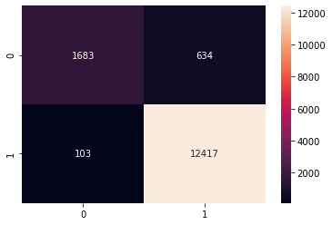

```python
sns.heatmap(cm, annot= True, fmt='d')
```

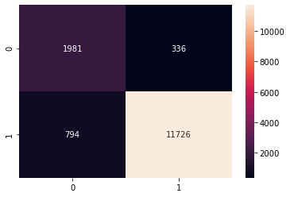

```python
sns.heatmap(cm1, annot= True, fmt='d')
```

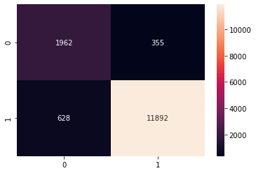

```python
sns.heatmap(cm2, annot= True, fmt='d')
```